# Bootstrap CIs

Taylor Ledford

2018-11-29 12:08:09

```r
library(tidyverse)
Delays <- read.csv("https://raw.githubusercontent.com/STAT-JET-ASU/Datasets/master/Chihara/FlightDelays.csv")
Popular <- read.csv("https://raw.githubusercontent.com/STAT-JET-ASU/Datasets/master/Instructor/popular.csv")
```

### Problem 1

Consider the Flight Delays dataset discussed in Chapter 1 of the Chihara & Hesterberg textbook, which contains data on selected flights departing from LaGuardia airport in 2009. Assume the data are a representative sample of flights and use only flights with a positive delay time.

1. Compute a traditional 95% confidence interval to estimate mean delay time for flights that are delayed.

```r
Delays <- Delays %>%
  filter(Delay >= 1)

delay <- Delays$Delay

n <- length(delay)

mean(delay) + qt(c(0.025, 0.975), n-1) * sd(delay)/sqrt(n)
```

```
## [1] 45.08696 51.81642
```

2. Compute a 95% bootstrap percentile interval to estimte mean delay time for flights that are delayed.

```r
n <- length(delay)
N <- 10^4

bootmean <- numeric(N)

for (i in 1:N){
  bootsample <- sample(delay, n, replace = TRUE)
  bootmean[i] <- mean(bootsample)
}

quantile(bootmean, c(0.025, 0.975))
```

```
##     2.5%    97.5%
## 45.15054 51.86798
```

3. The distribution of delays is quite right skewed. Using your bootstrap distribution, determine whether the sampling distribution of the sample mean is approximately normal in this situation.

ANSWER: From the graphs below the distribution of the sample mean does appear to be normal.

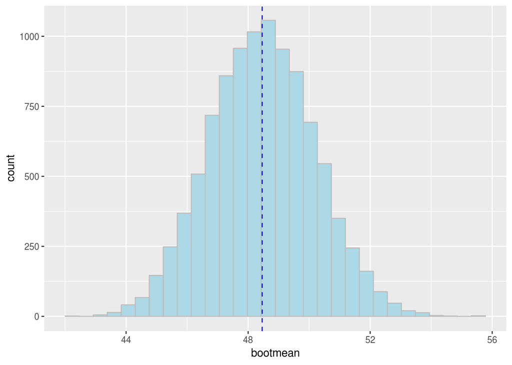

```r
ggplot(NULL, aes(x = bootmean)) +
  geom_histogram(fill = "lightblue", color = "gray") +
  geom_vline(xintercept = mean(bootmean), color = "blue", lty = 2)
```

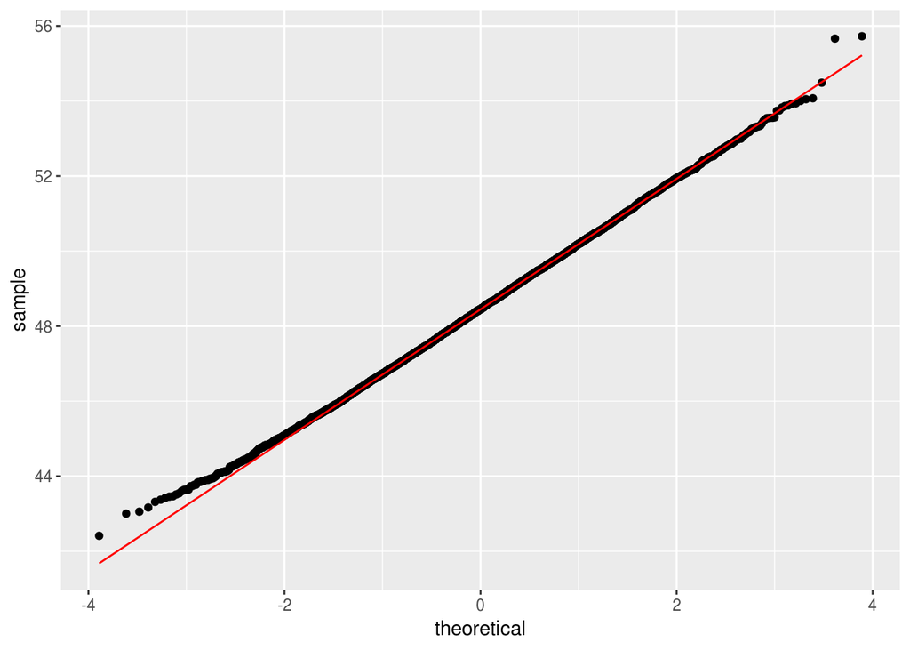

```r
ggplot(NULL, aes(sample = bootmean)) +
  geom_qq() +
  geom_qq_line(color = "red")
```

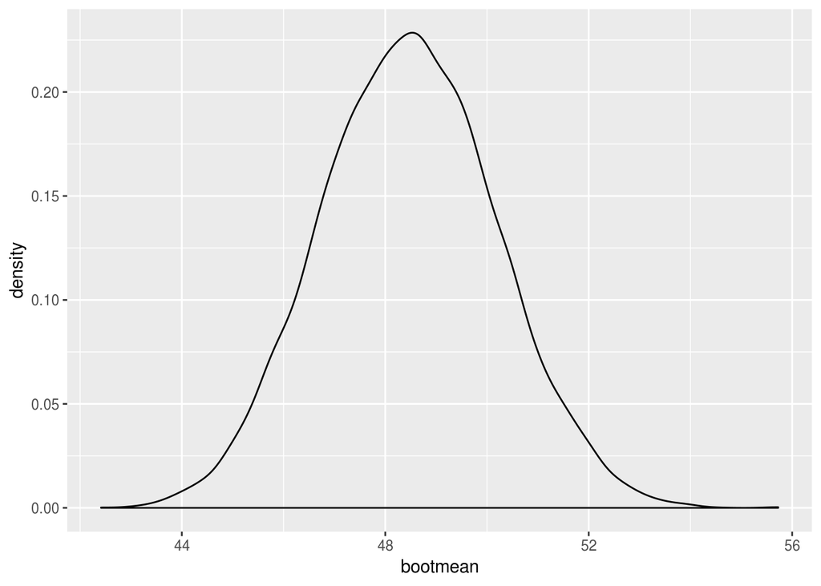

```r
ggplot(NULL, aes(x=bootmean)) +
  geom_density()
```

### Problem 2

Consider the Popular Kids dataset used in the class projects. Find a 95% bootstrap percentile interval to estimate the population proportion of kids who would choose grades as their top goal. Based on the interval, can we say with confidence that a majority of the population represented by this sample would choose grades? Explain.

ANSWER: I do not think there is enough evidence to say that the majority choose grades as their top goal, but I think there is strong evidence supporting that half of the population choose grades as their top goal.

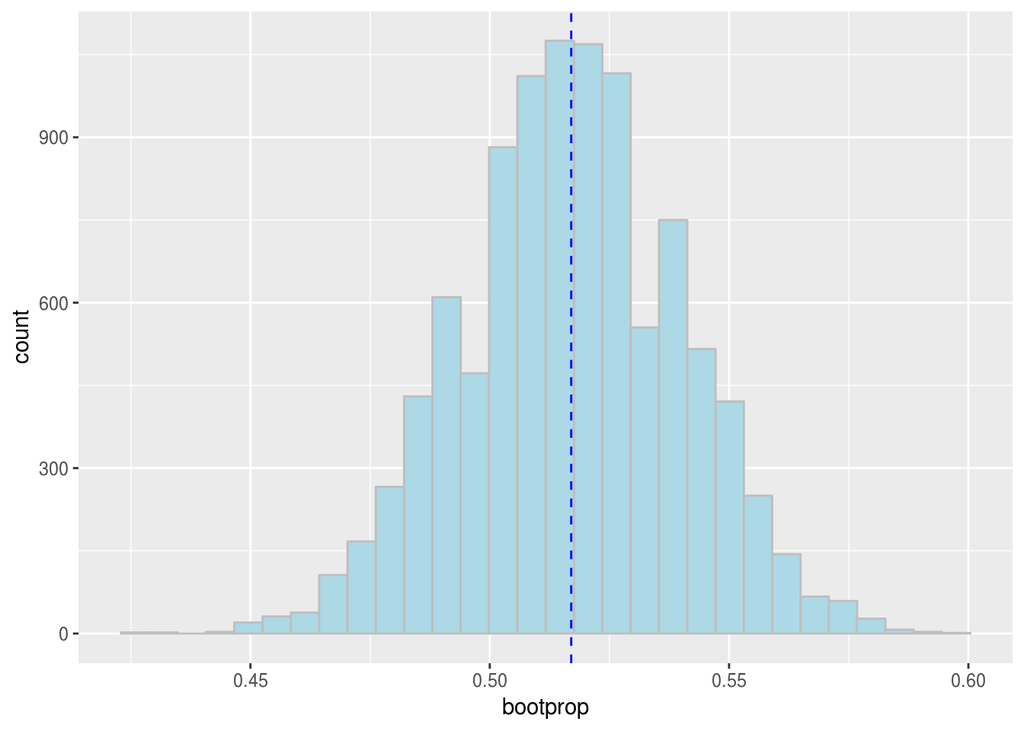

```r
Popular <- Popular %>%
  mutate(top_goal = ifelse(top_goal == "grades", "Grades", "Not Grades"))

phat <- mean(Popular$top_goal == "Grades")

level <- Popular$top_goal

n <- length(level)
N <- 10^4

bootprop <- numeric(N)

for (i in 1:N){
  bootsample <- sample(level, n, replace = TRUE)
  bootprop[i] <- mean(bootsample == "Grades")
}

ggplot(NULL, aes(x = bootprop)) +
  geom_histogram(fill = "lightblue", color = "gray") +
  geom_vline(xintercept = mean(bootprop), color = "blue", lty = 2)
```

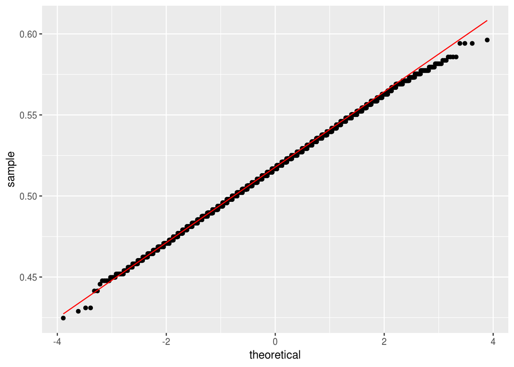

```r
ggplot(NULL, aes(sample = bootprop)) +
  geom_qq() +
  geom_qq_line(color = "red")
```

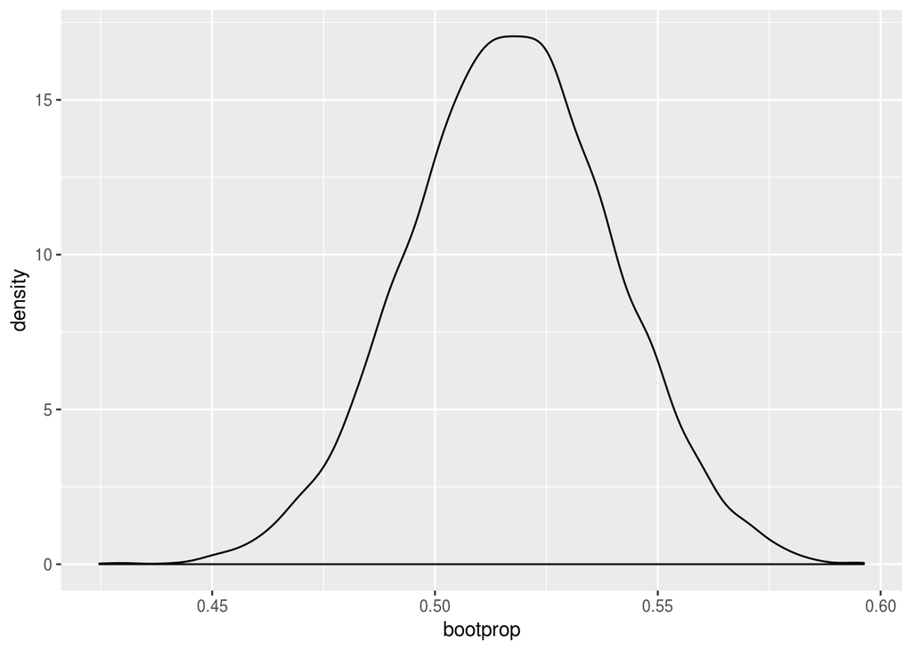

```r
ggplot(NULL, aes(x=bootprop)) +
  geom_density()
```

```r
quantile(bootprop, c(.025,.975))
```

```
##      2.5%     97.5%
## 0.4707113 0.5607218
```

### Problem 3

For the scenario in Problem 1, compute a 95% bootstrap percentile interval for the median delay time.

```r
n <- length(delay)
N <- 10^4

bootmedian <- numeric(N)

for (i in 1:N){
  bootsample <- sample(delay, n, replace = TRUE)
  bootmedian[i] <- median(bootsample)
}

quantile(bootmedian, c(0.025, 0.975))
```

```
##  2.5% 97.5%
##    26    31
```

END!!!